# M/STAT 502: Intermediate Mathematical Statistics

Spring 2021 Syllabus

# Course calendar

See our course calendar for material covered each week.

# Time and location

MWF 11:00-11:50am  
Wilson Hall 1-144

# Instructor contact information

[**Dr. Stacey Hancock**](http://www.math.montana.edu/shancock/)  
email: stacey.hancock@montana.edu  
Office: Wilson 2-195  
Phone: (406) 993-5350

*Virtual office hours*: See D2L for Zoom link.

- TBD
- By appointment - Please feel free to email me to schedule an appointment outside of office hours.

# Prerequisites

M/STAT 501: Intermediate Probability and Statistics.

Back to top

# Course materials

### Textbook

The required textbook for the course (and one that you’ll want to save for the rest of your career!) is *Statistical Inference*, 2nd edition by Casella and Berger, 2002.

### Statistical computing

We will be using the statistical software [R](https://www.r-project.org/) through the IDE [RStudio](https://rstudio.com/products/rstudio/) for simulations, data visualization, and statistical analyses. Students have four options for accessing this free software:

1. Download to your own laptop. (Note R and RStudio will not run on iPad, notebooks, or Chromebooks. If you have one of these devices, see the cloud-based option below.)
   - Download and install [R](https://cloud.r-project.org/).
   - Download and install [RStudio Desktop](https://rstudio.com/products/rstudio/).
2. Use RStudio through the [RStudio Cloud](https://login.rstudio.cloud/register?redirect=https%3A%2F%2Fclient.login.rstudio.cloud%2Foauth%2Flogin%3Fshow_auth%3D0%26show_login%3D1%26show_setup%3D1). This resource allows you to use RStudio through a web browser. It is free for use, but it does limit you to a certain number of project hours per month.
3. Use RStudio through an MSU [virtual machine](https://studentlabs.montana.edu/remotelabs/howto.html).
4. Use RStudio in an MSU on-campus computer lab.

View this [tutorial video on installing R and RStudio](https://greenwood-stat.shinyapps.io/InstallDemo/) if you would like additional installation instructions.

### Learning management

- [**D2L**](https://ecat1.montana.edu/): Announcements, gradebook, discussion forums.
  - *Important*: Make sure you are receiving email notifications for any D2L activity. In D2L, click on your name, then Notifications. Check that D2L is using an email address that you regularly check; you have the option of registering a mobile number. Check the boxes to get notifications for announcements, content, discussions, and grades.
  - If you have a question about the course materials, computing, or logistics, please post your question to your **D2L discussion board** instead of emailing your instructor. This ensures all students can benefit from the responses. Other students are encouraged to respond.
- [**Gradescope**](https://www.gradescope.com/saml): Submit and review homeworks and quizzes, review homework and quiz grades and feedback.

Back to top

# Course goals

This course will prepare you for future coursework in statistics. In addition to learning distribution theory, you will learn to think and reason statistically. My role, as the instructor, is to facilitate this type of learning by providing you with a variety of meaningful activities and opportunities to learn, as well as by creating an environment conducive for learning. This will manifest in a variety of ways: group work, direct instruction, individual practice, exploration and discovery activities, writing, discussions and/or student-led instruction. The course is structured for understanding, as opposed to mere memorization. Ultimately, you are responsible for your own learning, so please put into the class what you hope to get out of it.

### Learning outcomes

At the end of the course, students will understand:

1. Properties of sums of random variables, random samples from a normal distribution, order statistics, and convergence concepts including convergence in distribution and probability and the Central Limit Theorem.
2. Sufficiency and sufficient statistics, point estimation including method of moments and maximum likelihood, and methods of evaluating estimators.
3. Hypothesis testing including finding tests (likelihood ratio tests, Bayesian tests), power functions, methods of evaluating tests including the Neyman-Pearson Theorem and most powerful tests.
4. Interval estimation including finding good interval procedures (inverting test statistics, pivotal quantities, pivoting a cumulative distribution function, and Bayesian intervals), evaluating interval procedures including size and coverage probability, and other optimality criteria.
5. Asymptotic (large sample) considerations in point estimation, testing, and interval estimation including consistency and efficiency, asymptotic distributions of test statistics, and approximate interval construction.

Back to top

# Course expectations

In this course, you are expected to have professional behavior. You are expected to attend all class meetings on time, be curious, ask questions, seek opportunities to learn, and be open and responsive to constructive feedback. In addition:

- Be an active participant—statistics is not a spectator sport!
- Be committed, take your work seriously.
- Engage with the in-class activities and homework sets.
- Help others—if you understand the material being discussed, practice your mentoring skills. This does not mean sharing answers, but instead helping others understand the concepts.
- Complete assigned readings and read your textbook.

You are also expected to exhibit a professional demeanor (language, attitude) toward others. Disagreement during discussions is welcome and often productive in developing a deeper understanding of the concepts being discussed. However, disagreement in a discussion does not warrant yelling or disrespectful language or behavior. Unprofessional behavior that impedes on other students’ opportunity to learn will not be tolerated, and appropriate actions will be taken to prevent future occurrences. Anyone causing minor disturbances (e.g., cell phone usage or ringing) will be expected to bring treats for everyone else to the next class meeting.

Back to top

# Course assessment

Your grade in M/STAT 502 will contain the following components.

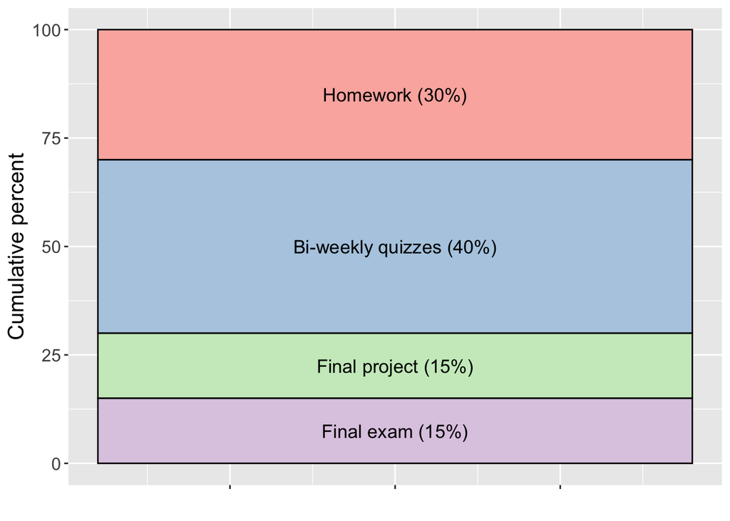

1. **Homework** (30%): The only way to learn probability and statistics is to practice working problems, and homework is therefore an essential part of the course. Homeworks will be assigned bi-weekly, alternating weeks with quizzes. Access the homework assignment and turn in the assignment via [Gradescope](https://www.gradescope.com/).
   - Homeworks will be due by **5:00pm on Wednesdays**.
   - Homework may be hand-written and scanned, or typed, but must be organized and legible. Papers that are too messy to grade will not receive credit.
   - Homework solutions will be graded partially on completeness and partially on accuracy.
   - Late homework should be avoided in all but the most dire emergencies. In the event of extreme circumstances, other arrangements will be considered if prior notification is provided.
   - See the policy and collaboration and academic misconduct section for guidance with regards to collaboration on homework assignments.
2. **Quizzes** (40%): We will have a short quiz via [Gradescope](https://www.gradescope.com/) every other Wednesday, alternating weeks with homework assignments.
   - Quizzes will be open book and open notes, but you must complete all work on your own. See the policy and collaboration and academic misconduct section for guidance with what is allowed on quizzes.
   - Quizzes will open at 11am and close at 1pm; you will have 45 minutes or until 1pm (whichever comes first) to complete the quiz once you start the quiz.
   - We will not hold class on quiz days. A video on course material will be posted in D2L in place of the class time we would have had, had the quiz been taken in person.
   - The lowest quiz score will be dropped.
3. **Final project** (15%): Communication (written and oral) is an essential part of any job, either in industry or academia. To help develop these skills and extend concepts we have learned in class to other real-world applications, you will complete a final project. You may choose to work individually or with a partner. The project will involve both a written report, and an 8-10-minute presentation, given in class during the last week of classes. More information will be provided as the semester progresses.
4. **Final exam** (15%): As M/STAT 502 is the second semester of a one-year sequence, and the material is the basis for part of the MS comprehensive exams, we will have a take-home final exam during finals week. Though content on the final exam will not directly cover concepts in M/STAT 501, concepts build on each other, and the final exam content will be a chance to synthesize key ideas and practice for the MS comps. As with quizzes, the final exam is open book and open notes, but all work must soley by your own and any sources used must be cited. See the policy and collaboration and academic misconduct section for guidance with what is allowed on quizzes.

Letter grades generally follow the typical scale:

93-100 = A  
90-92 = A-  
88-89 = B+  
83-87 = B  
80-82 = B-  
etc.

These cutoffs may be adjusted down (never up!) at the end of the semester, depending on the grade distribution in the course. Thus, a 93% will guarantee an A, a 90% will guarantee an A-, etc.

Back to top

# COVID-19-related expectations

### Wearing face coverings in classrooms is required

Face coverings that cover both your nose and mouth are required in all indoor spaces and all enclosed or partially enclosed outdoor spaces. MSU requires all students to wear face masks or cloth face coverings in classrooms, laboratories and other similar spaces where in-person instruction occurs. MSU requires the wearing of masks in physical classrooms to help mitigate the transmission of SARS-CoV-2, which causes COVID-19. The MSU community views the adoption of these practices as a mark of good citizenship and respectful care of fellow classmates, faculty, and staff.

The complete details about MSU’s mask requirement can be found at https://www.montana.edu/health/coronavirus/index.html.

These requirements from the Office of the Commissioner of Higher Education are detailed in the [MUS Healthy Fall 2020 Guidelines, Appendix B](https://www.mus.edu/coronavirus/Appendix%20B%20Face%20Covering%20Requirement.pdf).

For more information: https://www.montana.edu/health/coronavirus/prevention/index.html

Compliance with the face-covering protocol is expected. If a you do not comply with a classroom rule, you may be requested to leave class. Section 460.00 of the [MSU Code of Student Conduct](https://www.montana.edu/policy/student_conduct/#460) covers “disruptive student behavior.”

### Accommodations for not wearing a mask

Individuals whose unique and individual circumstances require an exception to the face covering requirement, as indicated by a medical professional, may request one in accordance with the campus ADA policies. Students should contact the Office of Disability Services at 994-2824 or drv@montana.edu to receive written permission from the Office of Disability Services at MSU. It is strongly recommended that students make contact prior to arriving on campus in order to provide adequate time for their request to be evaluated.

### Health-related class absences

Please evaluate your own health status regularly and refrain from attending class and other on-campus events if you are ill. MSU students who miss class due to illness will be given opportunities to access course materials online. You are encouraged to seek appropriate medical attention for treatment of illness. In the event of contagious illness, please do not come to class or to campus to turn in work. Instead notify us by email about your absence as soon as practical, so that accommodations can be made. Please note that documentation (a Doctor’s note) for medical excuses is not required. MSU University Health Partners–as part their commitment to maintain patient confidentiality, to encourage more appropriate use of healthcare resources, and to support meaningful dialogue between instructors and students–does not provide such documentation.

Back to top

# Diversity and inclusivity statements

**Respect for Diversity**: It is our intent that students from all diverse backgrounds and perspectives be well-served by this course, that students’ learning needs be addressed both in and out of class, and that the diversity that students bring to this class be viewed as a resource, strength and benefit. It is our intent to present materials and activities that are respectful of diversity: gender identity, sexual orientation, disability, age, socioeconomic status, ethnicity, race, religion, culture, perspective, and other background characteristics. Your suggestions about how to improve the value of diversity in this course are encouraged and appreciated. Please let us know ways to improve the effectiveness of the course for you personally or for other students or student groups.

In addition, in scheduling exams, we have attempted to avoid conflicts with major religious holidays. If, however, we have inadvertently scheduled an exam or major deadline that creates a conflict with your religious observances, please let us know as soon as possible so that we can make other arrangements.

**Support for Inclusivity**: We support an inclusive learning environment where diversity and individual differences are understood, respected, appreciated, and recognized as a source of strength. We expect that students, faculty, administrators and staff at MSU will respect differences and demonstrate diligence in understanding how other peoples’ perspectives, behaviors, and worldviews may be different from their own.

Back to top

# Policy on collaboration and academic misconduct

In M/STAT 502, at a minimum, any act of academic dishonesty, which includes but is not limited to plagiarism, cheating, multiple submissions, or facilitating others’ misconduct, will result in a score of zero on the assignment/quiz/exam in question and notification of department and university officials. Further action may be taken as warranted. If you have any questions about the limits of collaboration or about using and citing sources, you are expected to ask for clarification.

### Homework

*After attempting to complete homework problems on your own*, you are permitted to collaborate on homework in a constructive manner for all involved—each individual in the collaboration needs to ensure they understand and could explain the process of solving each problem. While I encourage you to talk through problems with fellow students, the work you turn in must be your own and must be written in your own words (unless the assignment specifically states otherwise).

**Each homework will require a “citations” page where you cite all sources (including web forums such as Stack Overflow) and individuals used to complete that homework assignment.** Paraphrasing or quoting another’s work without citing the source is a form of academic dishonesty. Even inadvertent or unintentional misuse or appropriation of another’s work (such as relying heavily on source material that is not expressly acknowledged) is considered plagiarism. Homework assignments that do not cite sources or individuals, or assignments where answers are copied directly from another student, will be considered and treated as plagiarism, and will receive a zero grade. If you have any questions about the limits of collaboration or about using and citing sources, you are expected to ask for clarification.

### Quizzes and Final exam

Quizzes and the take-home final exam in this course will be open notes and open book; you may also use any resources that one might encounter in a research setting. However, you may not discuss quizzes and the final exam with other students or individuals. Complete citations for all sources (including web forums such as Stack Overflow) used on the quiz/exam must be included.

### MSU policy

Students in an academic setting are responsible for approaching all assignments with rigor, integrity, and in compliance with the University Code of Student Conduct. This responsibility includes:

1. consulting and analyzing sources that are relevant to the topic of inquiry;
2. clearly acknowledging when they draw from the ideas or the phrasing of those sources in their own writing;
3. learning and using appropriate citation conventions within the field in which they are studying; and
4. asking their instructor for guidance when they are uncertain of how to acknowledge the contributions of others in their thinking and writing.

[More information about Academic Misconduct from the Dean of Students](https://www.montana.edu/deanofstudents/syllabus.html)

Back to top